# Clase 4. Explorando datos categóricos

Práctica R

Germán Rosati y Laia Domenech Burin

14 marzo, 2022

#Exploración de datos categóricos En este capítulo vamos a trabajar sobre las diferentes formas en las que podemos resumir una o dos variables cualitativas o categóricas. Seguiremos usando la EPH y vamos a calcular algunas tablas.

# Librerías

Cargamos los paquetes que vamos a utilizar:

```r
library(tidyverse)
library(eph)
```

# Datos y los etiqueto

Importamos la base de individuos de la EPH del 2do. trimestre de 2021 y la etiquetamos.

```r
df <- get_microdata(year = 2021, trimester = 2, type = "individual")
df <- organize_labels(df=df, type='individual') # Vamos a etiquetar la base
df <- df %>% mutate_at(vars(CH03, CH04, CH07:CAT_INAC), ~as.character(.))
```

# Explorando los datos

## Distribuciones de frecuencia simples (una variable)

A continuación, vamos a concentrarnos en la exploración de datos categóricos a través de medidas resumen, tablas y visualizaciones.

R base tiene funciones para generar la tabla de frecuencias de una variable:

- `table`: para hacer las frecuencias simples
- `prop.table`: para hacer las frecuencias proporcionales.

```r
table(df$CH04)
```

```
##
## Mujer Varon
## 24483 22602
```

```r
prop.table(table(df$CH04))
```

```
##
##     Mujer     Varon
## 0.5199745 0.4800255
```

Ahora bien, en la clase 2 también vimos el uso de las funciones `group_by` y `summarize`. ¿Qué realizaban?

Nos devuelven las frecuencias de las categorías de una variable. Esto nos permite ver también la **moda** de una variable categórica. Si queremos ordenar las frecuencias en orden ascendente hay que usar la función `arrange()`.

```r
df %>% group_by(ESTADO)%>%
  summarize(n=n())%>%
  arrange(n)%>%
  mutate(frec_acum = cumsum(n))
```

```
## # A tibble: 5 x 3
##   ESTADO                                                             n frec_acum
##   <chr>                                                          <int>     <int>
## 1 Entrevista individual no realizada (no respuesta al cuestiona…    89        89
## 2 Desocupado                                                      1737      1826
## 3 Menor de 10 anios.                                              6086      7912
## 4 Ocupado                                                        19408     27320
## 5 Inactivo                                                       19765     47085
```

Podemos hacer el cálculo por proporción con operaciones matematicas.

```r
freq_prop <- df %>% group_by(ESTADO)%>%
  summarize(n=n())%>%
  arrange(n)%>%
  mutate(frec_acum = cumsum(n))%>%
  ungroup()%>%
  mutate(total = sum(n), #Creo una columna que contenga el total de observaciones
         perc = (n/total)*100,
         perc_acum = (frec_acum/total)*100) #Calculo el porcentaje

freq_prop
```

```
## # A tibble: 5 x 6
##   ESTADO                                      n frec_acum total   perc perc_acum
##   <chr>                                   <int>     <int> <int>  <dbl>     <dbl>
## 1 Entrevista individual no realizada (no…    89        89 47085  0.189     0.189
## 2 Desocupado                               1737      1826 47085  3.69      3.88
## 3 Menor de 10 anios.                       6086      7912 47085 12.9      16.8
## 4 Ocupado                                 19408     27320 47085 41.2      58.0
## 5 Inactivo                                19765     47085 47085 42.0     100
```

## Tablas de contingencia (dos variable)

La siguiente tabla nos resume la condición de actividad en función del sexo.

| ESTADO | Mujer | Varon | Total |
| --- | --- | --- | --- |
| Desocupado | 854 | 883 | 1737 |
| Inactivo | 12147 | 7618 | 19765 |
| Ocupado | 8485 | 10923 | 19408 |
| Total | 21486 | 19424 | 40910 |

Cada valor en la tabla (celda) representa la cantidad de veces que una combinación particular de valores ocurrieron. Asi, Por ejemplo, la tabla nos dice que hubo 12.147 personas inactivas que eran mujeres. Los *totales de columna* proveen información sobre el total de casos para cada columna y lo propio sucede con los *totales de fila*-

Otra forma común de representar esto es mediante un gráfico “facetado”:

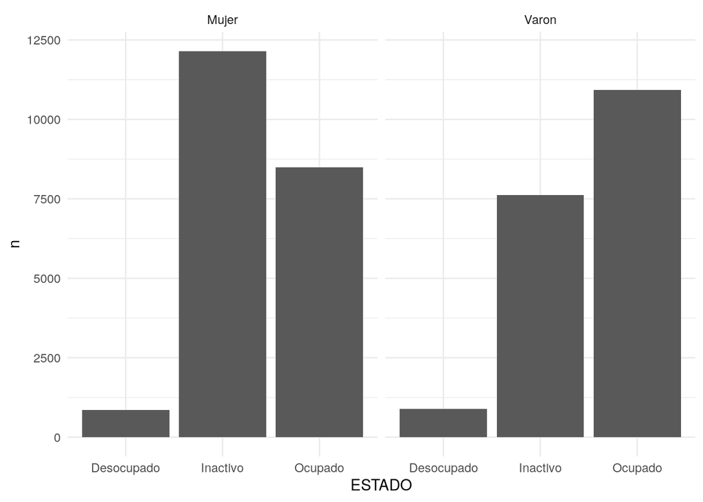

El gráfico anterior nos muestra la misma información que la tabla: cada panel es una de las columnas de la tabla, en el eje X encontramos las filas de la tabla y en el eje Y el conteo de valores. Sin embargo, falta algo…

## Visualizando dos variables categóricas

### Gráficos de barra con dos variables

Podemos mostrar las distribuciones de dos variables categóricas en un gráfico de barras al mismo tiempo. Estos gráficos suelen ser útiles para visualizar la relación entre dos variables categóricas. La figura siguiente muestra tres gráficos de este tipo que visualizan la relación entre sexo y condición de actividad. El siguiente es un gráfico de barras apiladas:

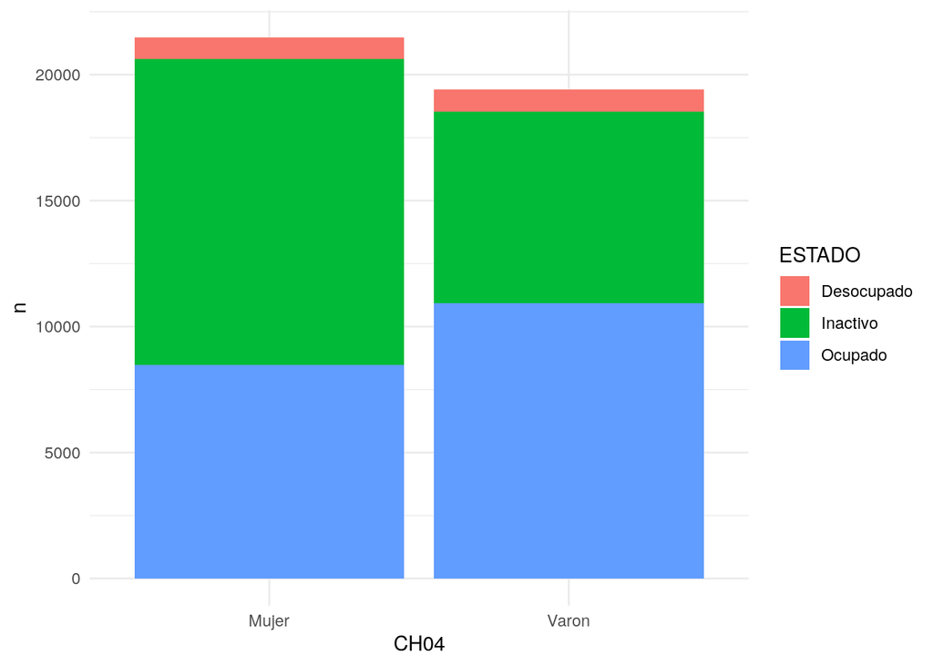

```r
df %>%
    filter(ESTADO %in% c("Ocupado", "Desocupado", "Inactivo")) %>%
  group_by(CH04, ESTADO) %>%
  summarise(n=n()) %>%
  ggplot() +
    geom_col(aes(x=CH04, y=n, fill=ESTADO), position="stack") +
    theme_minimal()
```

Este gráfico muestra que las mujeres son más que los varones. Es difícil decir, basándose únicamente en este diagrama, cómo las diferentes condiciones de actividad varían según sexo. Pareciera ser que los varones están ocupadas en mayor medida.

La gráfica B es una gráfica de barras “desplazadas”.

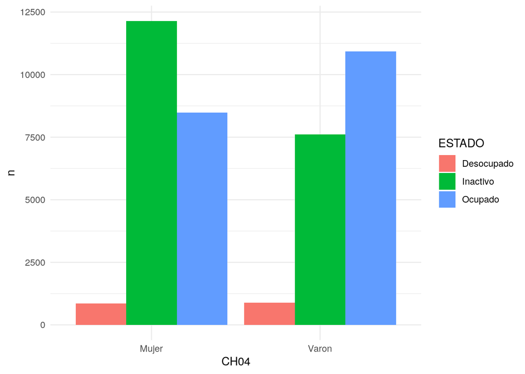

```r
df %>%
    filter(ESTADO %in% c("Ocupado", "Desocupado", "Inactivo")) %>%
  group_by(CH04, ESTADO) %>%
  summarise(n=n()) %>%
  ggplot() +
    geom_col(aes(x=CH04, y=n, fill=ESTADO), position='dodge') +
    theme_minimal()
```

Este gráfico muestra claramente que dentro de cada sexo la principal forma de actividad es diferente: ocupados en varones, inactivas en mujeres.

Finalmente, el gráfico C es un gráfico de barras estandarizado (también conocido como gráfico de barras rellenas).

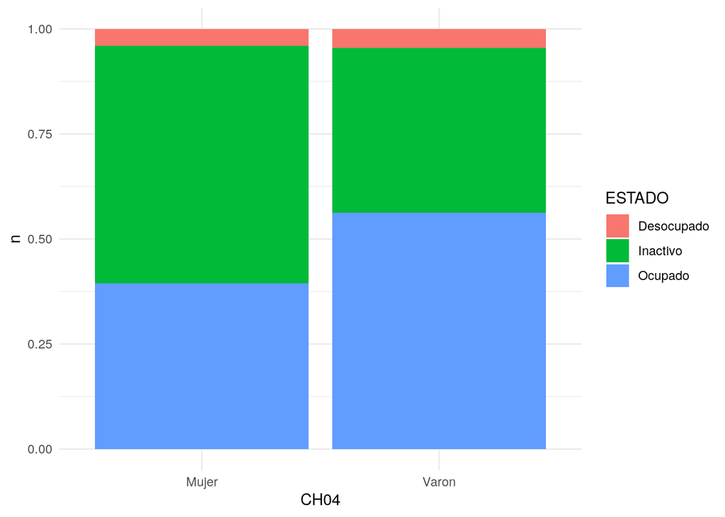

```r
df %>%
    filter(ESTADO %in% c("Ocupado", "Desocupado", "Inactivo")) %>%
  group_by(CH04, ESTADO) %>%
  summarise(n=n()) %>%
  ggplot() +
    geom_col(aes(x=CH04, y=n, fill=ESTADO), position = 'fill') +
    theme_minimal()
```

Este gráfico muestra con mayor claridad que la condición de actividad más común entre mujeres es la inactividad y entre los varones la ocupación. A su vez, la proporción de desocupados es muy similar entre varones y mujeres.

El gráfico de barras apiladas es más útil cuando es razonable asignar una variable como variable explicativa (aquí, sexo `CH04`) y la otra variable como respuesta (aquí, condición de actividad `ESTADO`), ya que estamos agrupando primero por una variable y luego separándola por las demás. .

El gráfico de barras apiladas estandarizado es útil si la variable principal en el gráfico de barras apiladas está relativamente desequilibrada. En este caso la distribucion por `CH04` no está muy desequilibrada pero aún así resulta más complejo en ese gráfico de barras apiladas simple verificar una asociación. La principal desventaja de la versión estandarizada es que perdemos todo sentido de cuántos casos representa cada una de las barras.

## Porcentajes de filas y columnas

En las secciones anteriores, inspeccionamos visualizaciones de dos variables categóricas en gráficos de barras. Sin embargo, no hemos discutido cómo se calculan los valores. En esta sección investigaremos cómo calcular las diferentes proporciones en una tabla de contingencia.

La siguiente tabla muestra las *proporciones por fila* para la primera tabla que vimos antes. Las mismas se calculan como los conteos divididos por los totales de las filas.

El valor 12147 en la intersección de mujer e inactivo se reemplaza por: $\frac{12147}{19765} = 0.615$. Entonces, ¿qué representa 0,615? Corresponde a la proporción de encuestades inactivas que son mujeres.

| ESTADO | Mujer | Varon | Total |
| --- | --- | --- | --- |
| Desocupado | 0.492 | 0.508 | 1.000 |
| Inactivo | 0.615 | 0.385 | 1.000 |
| Ocupado | 0.437 | 0.563 | 1.000 |
| Total | 0.525 | 0.475 | 1.000 |

Una tabla de contingencia con las *proporciones por columnas* se calcula de manera similar, donde cada una se calcula como el recuento dividido por el total de la columna correspondiente. La siguiente es una tabla de este tipo, y aquí el valor 0.57 indica que el 57% de las mujeres son inactivas. Esta tasa es notablemente superior a la de los varones (0.39). A su vez, los varones tienen una mayor tasa de ocupación. Esto constituye evidencia de que las variables pueden estar asociadas.

| ESTADO | Mujer | Varon | Total |
| --- | --- | --- | --- |
| Desocupado | 0.040 | 0.045 | 0.042 |
| Inactivo | 0.565 | 0.392 | 0.483 |
| Ocupado | 0.395 | 0.562 | 0.474 |
| Total | 1.000 | 1.000 | 1.000 |

Las proporciones de fila y columna también pueden considerarse proporciones condicionales, ya que nos informan sobre la proporción de observaciones en un nivel dado de una variable categórica condicional en el nivel de otra variable categórica.

## Gráficos con `ggplot()`

Una de las grandes ventajas de `tidyverse` es el paquete para realizar gráficos, `ggplot`. Incluye funciones para realizar uan gran variedad de visualizaciones. Su concepto central es la asignación (*mapping* en inglés) de atributos estéticos a los valores que toma una variable. Dicho de otra forma, como mostrar de modo perceptible a la vista la diferencia entre valores: con distintos colores, distintos tamaños, distintas posiciones en un gráfico, etc.

Su funcionamiento básico consiste en:

- una llamada a la función `ggplot()`, pasándole un dataset y una “asignación de atributos estéticos” (*aesthetic mapping* en inglés) usando `aes()`
- al menos una capa “geom”, que define el recurso gráfico que mostrará los datos; por ejemplo `geom_bar()` para dibujar barras.

Por ejemplo, podemos ver en forma gráfica la frecuencia de los niveles de actividad:

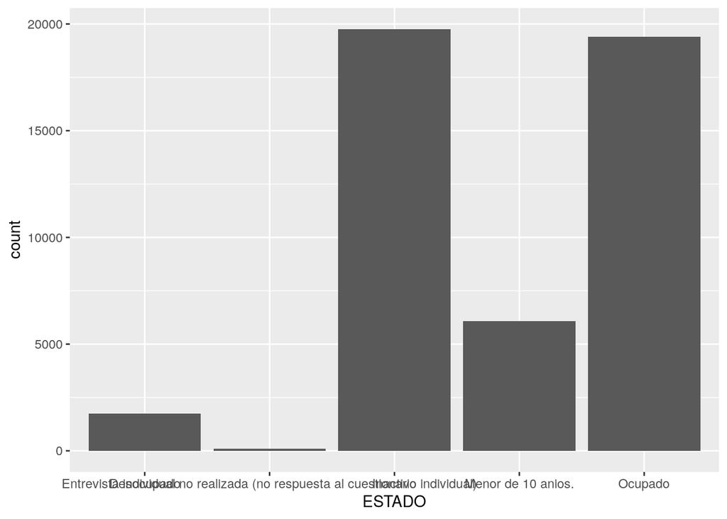

```r
df %>%
  ggplot(aes(x=ESTADO))+
  geom_bar()
```

Este paquete tiene un uso cohesionado con `tidyverse`, de manera que se le puede pasar un objeto mediante pipes.

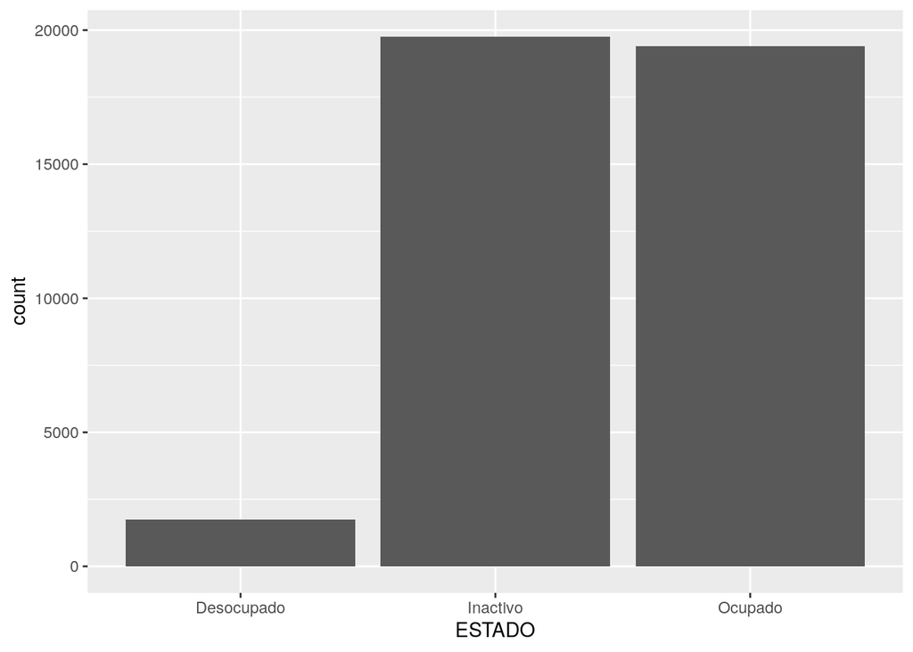

```r
df %>%
  filter(ESTADO != "Menor de 10 anios." & ESTADO != "Entrevista individual no realizada (no respuesta al cuestionario individual)")%>% #Filtro los casos que no corresponden
  ggplot(aes(x=ESTADO))+
  geom_bar()
```

`geom_bar()` calcula automáticamente la frecuencia de la variable que le pasamos. Sin embargo, también podemos usar `geom_col()`. A esta función se le pueden pasar atributos `x` e `y`, y se puede, por ejemplo, graficar el porcentaje que calculamos más arriba.

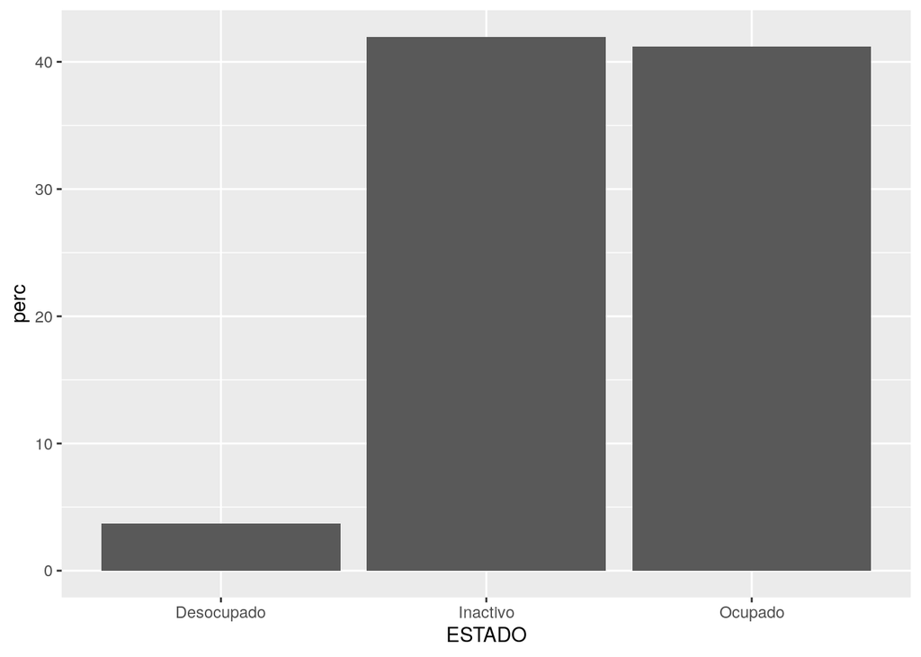

```r
freq_prop %>%
  filter(ESTADO != "Menor de 10 anios." & ESTADO != "Entrevista individual no realizada (no respuesta al cuestionario individual)")%>%
        ggplot(aes(x=ESTADO, y = perc))+
        geom_col()
```

Podemos usar el atributo estético `fill`, que es similar `color` pero se aplica como relleno, “pintando” por dentro áreas como las barras de un gráfico o las regiones en un mapa (`color`, en cambio, se usa para líneas y puntos). Por ejemplo, podemos usar el atributo estético `fill` con `geom_col()` para pintar el interior de cada barra. Vamos a probarlo. Generemos un gráfico de `CH04` en las $x$, la frecuencia en las $y$ y coloreemos el interior de las barras según el `ESTADO`.

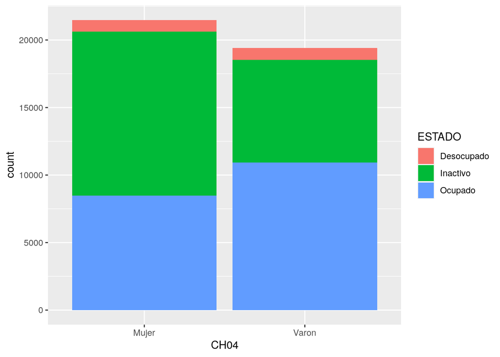

```r
df %>%
  filter(ESTADO != "Menor de 10 anios." & ESTADO != "Entrevista individual no realizada (no respuesta al cuestionario individual)")%>%
  ggplot(aes(x=CH04, fill=ESTADO))+
  geom_bar()
```

El atributo `fill` tiene el atributo `position`, que nos permite hacer tres tipos de gráficos: `dodge`, `stack` y `fill`. En el primer ejemplo que vimos están ubicados con `stack.`

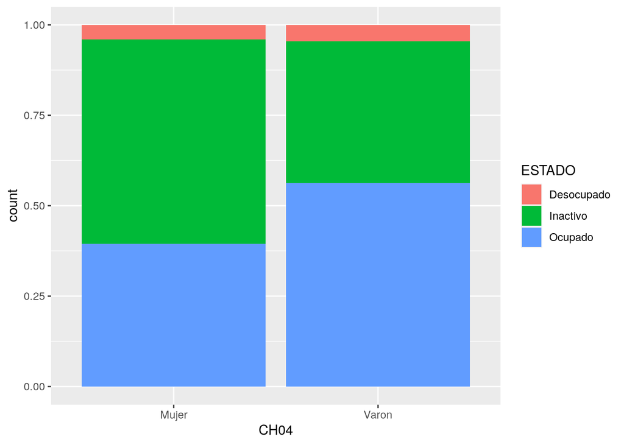

```r
df %>%
  filter(ESTADO != "Menor de 10 anios." & ESTADO != "Entrevista individual no realizada (no respuesta al cuestionario individual)")%>%
  ggplot(aes(x=CH04, fill=ESTADO))+
  geom_bar(position = "fill")
```

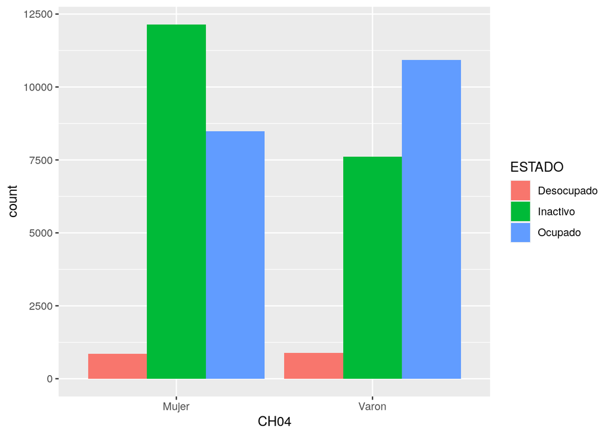

```r
df %>%
  filter(ESTADO != "Menor de 10 anios." & ESTADO != "Entrevista individual no realizada (no respuesta al cuestionario individual)")%>%
  ggplot(aes(x=CH04, fill=ESTADO))+
  geom_bar(position = "dodge")
```

Este tipo de gráficos son una forma útil de comparar o visualizar la relación entre dos variables. Estos graficos que estuvimos viendo nos muestran que los varones tienen un mayor nivel de ocupación que las mujeres. Otra función útil que tiene `ggplot`, para realizar comparaciones por tres variables, es `facet_wrap()`. Por ejemplo, veamos si estos niveles de actividad por género son iguales entre los niveles educativos alcanzados:

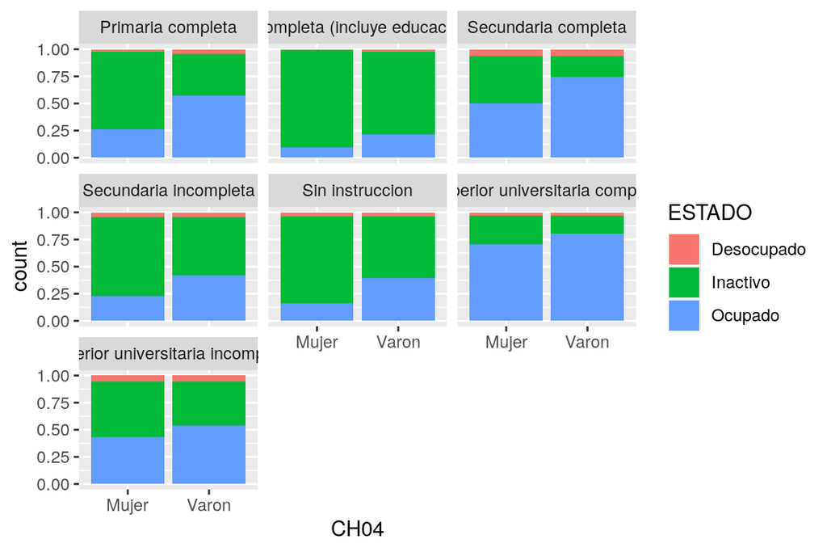

```r
df %>%
  filter(ESTADO != "Menor de 10 anios." & ESTADO != "Entrevista individual no realizada (no respuesta al cuestionario individual)")%>%
  ggplot(aes(x=CH04, fill=ESTADO))+
  geom_bar(position = "fill")+
  facet_wrap(.~NIVEL_ED)
```

- **¿Qué podemos decir sobre la condición de actividad según este gráfico?**

Finalmente, también tenemos la opción de pasar la capa `labs` para para agregar título, subtítulo y cambiar los nombres del eje x e y.

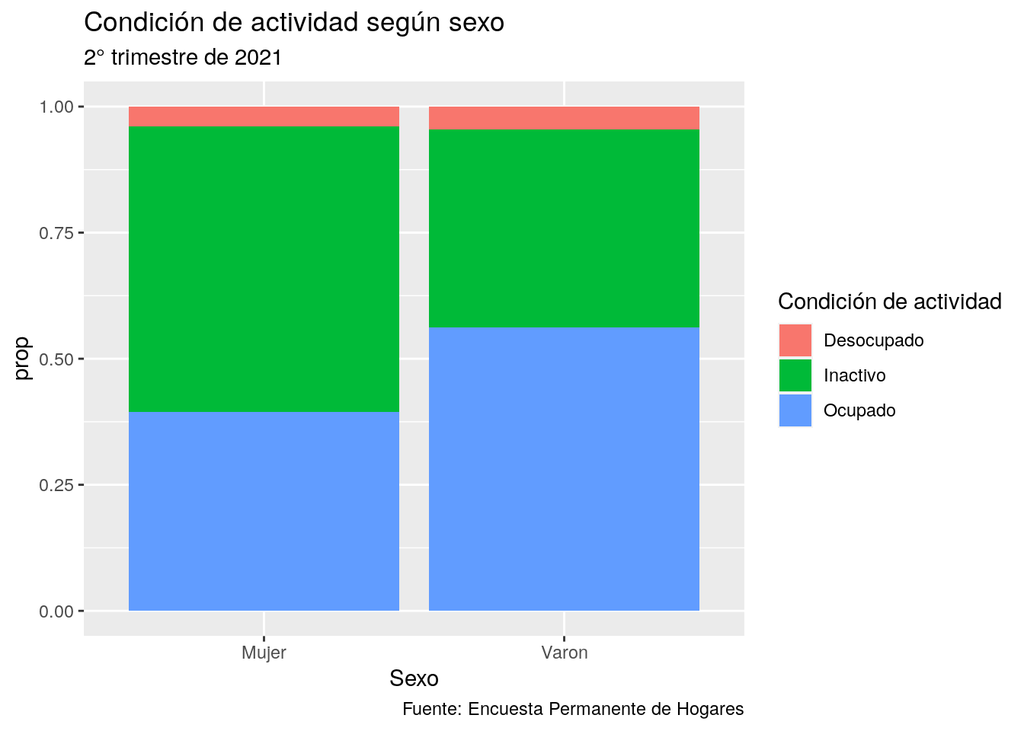

```r
df %>%
  filter(ESTADO != "Menor de 10 anios." & ESTADO != "Entrevista individual no realizada (no respuesta al cuestionario individual)")%>%
  ggplot(aes(x=CH04, fill=ESTADO))+
  geom_bar(position = "fill")+
  labs(title = "Condición de actividad según sexo",
             subtitle = "2° trimestre de 2021",
             x = "Sexo",
             y = "prop",
             fill = "Condición de actividad",
             caption = "Fuente: Encuesta Permanente de Hogares")
```